# Lab 5

Seungah Lee

**Load Data**

```r
library(ggplot2)
library(tidyverse)
library(readxl)
library(lubridate)
library(maps)
```

```r
acc <- read.csv("https://raw.githubusercontent.com/xdaiISU/ds202materials/master/hwlabs/fars2017/accident.csv", stringsAsFactors = FALSE)

person <- read.csv("https://raw.githubusercontent.com/xdaiISU/ds202materials/master/hwlabs/fars2017/person.csv", stringsAsFactors = FALSE)
```

1. Are there some days of the week where more accidents happen than the others (see FARS manual, use variable DAY_WEEK)?

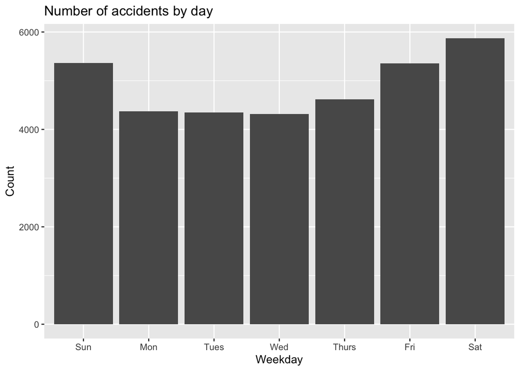

```r
accday <- acc %>%
  within(DAY_WEEK <- factor(DAY_WEEK, labels = c('Sun', 'Mon', 'Tues', 'Wed', 'Thurs', 'Fri', 'Sat')))

ggplot(accday, aes(x=DAY_WEEK)) +
  geom_bar() +
  labs(title="Number of accidents by day", x="Weekday", y="Count")
```

The most accidents occur on Saturdays, followed by accidents on Sundays and Fridays.

2. Create a data frame containing the persons who are fatally hurt in the accidents (look up variable INJ_SEV)

```r
fatal <- person %>%
  filter(INJ_SEV == '4')

head(fatal)
```

|  | STATE | ST_CASE | VE_FORMS | VEH_NO | PER_NO | STR_VEH | COUNTY | DAY | MONTH | HOUR | MINUTE | RUR_URB | FUNC_SYS | HARM_EV | MAN_COLL | SCH_BUS | MAKE | MAK_MOD | BODY_TYP | MOD_YEAR | TOW_VEH | SPEC_USE | EMER_USE | ROLLOVER | IMPACT1 | FIRE_EXP | AGE | SEX | PER_TYP | … |
| --- | --- | --- | --- | --- | --- | --- | --- | --- | --- | --- | --- | --- | --- | --- | --- | --- | --- | --- | --- | --- | --- | --- | --- | --- | --- | --- | --- | --- | --- | --- |
| 1 | 1 | 10001 | 1 | 1 | 1 | 0 | 73 | 19 | 2 | 23 | 35 | 2 | 1 | 38 | 0 | 0 | 20 | 20421 | 15 | 2004 | 1 | 0 | 0 | 0 | 12 | 0 | 42 | 1 | 1 | … |
| 2 | 1 | 10002 | 1 | 1 | 1 | 0 | 89 | 14 | 2 | 14 | 59 | 2 | 1 | 1 | 0 | 0 | 37 | 37402 | 14 | 2005 | 0 | 0 | 0 | 9 | 0 | 0 | 43 | 1 | 1 | … |
| 3 | 1 | 10003 | 3 | 2 | 1 | 0 | 101 | 31 | 1 | 20 | 31 | 2 | 1 | 12 | 1 | 0 | 2 | 2404 | 14 | 2003 | 0 | 0 | 0 | 0 | 6 | 0 | 47 | 1 | 1 | … |
| 4 | 1 | 10004 | 1 | 1 | 1 | 0 | 73 | 1 | 1 | 16 | 55 | 2 | 4 | 30 | 0 | 0 | 30 | 30046 | 4 | 2014 | 0 | 0 | 0 | 1 | 11 | 0 | 18 | 1 | 1 | … |
| 5 | 1 | 10005 | 1 | 1 | 1 | 0 | 13 | 1 | 1 | 20 | 0 | 1 | 1 | 35 | 0 | 0 | 12 | 12471 | 34 | 2010 | 0 | 0 | 0 | 1 | 12 | 0 | 67 | 2 | 1 | … |
| 6 | 1 | 10006 | 2 | 1 | 1 | 0 | 49 | 6 | 1 | 18 | 40 | 1 | 1 | 34 | 0 | 0 | 49 | 49032 | 4 | 1997 | 0 | 0 | 0 | 1 | 11 | 0 | 18 | 2 | 1 | … |

3. Create a data frame containing the most dangerous vehicle make in each state. The number of persons fatally hit in the vehicle make is used to assess the (non-)safety of a make. Make sure to handle the missing values appropriately. (look up variable MAKE)

```r
danger <- fatal %>%
  drop_na(MAKE) %>%
  group_by(STATE, MAKE) %>%
  summarise(Accidents = n()) %>%
  group_by(STATE) %>%
  filter(Accidents == max(Accidents))
head(danger)
```

| STATE | MAKE | Accidents |
| --- | --- | --- |
| 1 | 12 | 138 |
| 2 | 12 | 9 |
| 4 | 20 | 88 |
| 5 | 20 | 88 |
| 6 | 49 | 351 |
| 8 | 12 | 63 |

4. Create a map, and label each state with the most dangerous vehicle. Discuss the definition of the most dangerous vehicle, and what you find from the map. (Hint: Read the description for the STATE and COUNTY columns in the FARS manual. The state & county codes are Geographic Locator Codes (GLCs) from the General Services Administration’s (GSA) publication. Use readxl::read_xlsx to read in the GLCs.)

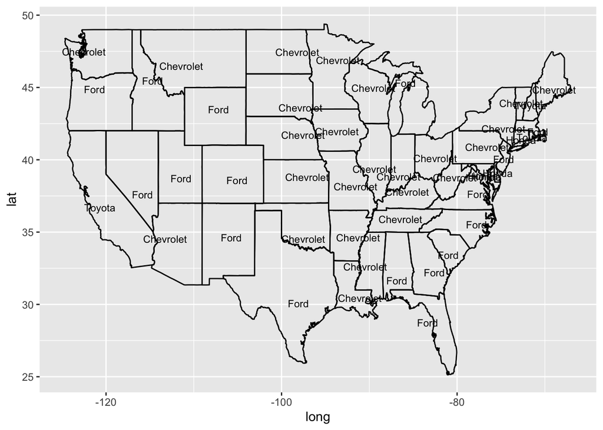

```r
glc <- readxl::read_xlsx("FRPP_GLC_-_United_StatesSep292020.xlsx")
states <- map_data('state')

state_code <- glc %>% mutate('State Code' = as.numeric(`State Code`))

vehicle <- danger %>%
  inner_join(state_code %>% select("State Name", "State Code"), by = c("STATE" = "State Code")) %>% distinct()

vehicle$`State Name` <- tolower(vehicle$"State Name")

perstate <- states %>%
  left_join(vehicle %>% select("State Name", "MAKE"), by = c("region"= "State Name"))

com <- perstate %>%
  group_by(region) %>%
  summarise(long = mean(long), lat = mean(lat), make = min(MAKE))

com$make <- factor(com$make, levels = c(12, 20, 37, 49), labels = c("Ford", "Chevrolet", "Honda", "Toyota"))

ggplot(perstate %>% group_by(region), aes(x = long, y = lat)) +
  geom_path(aes(group=group)) +
  geom_text(data = com, aes(label = make), size = 3)
```

5. Join the accident and person table (work out which variable(s) to use)

```r
accper <- acc %>%
  select(c(DAY_WEEK, STATE, HOUR)) %>%
  inner_join(person %>% select(c(STATE, SEX)), by = 'STATE')
```

6. Tally the number of accidents by day of the week (DAY_WEEK), hour of the day (HOUR) and gender (SEX). Visualize the results.

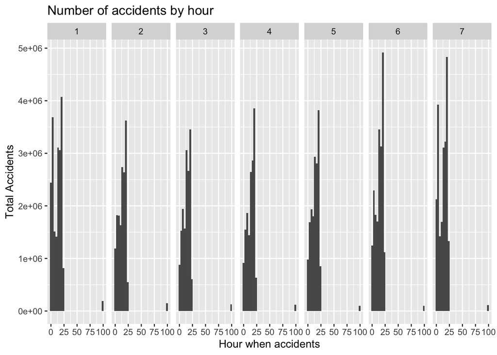

```r
acctal <- accper %>%
  group_by(DAY_WEEK, HOUR, SEX) %>%
  summarise(n = n())

acctal %>%
  ggplot(aes(x = HOUR, weight = n, fill = SEX)) +
  geom_histogram() +
  facet_grid(~DAY_WEEK) +
  labs(title="Number of accidents by hour", x="Hour when accidents", y="Total Accidents", fill="Gender")
```

7. Now plot a choropleth map of the number of deaths on a county level.

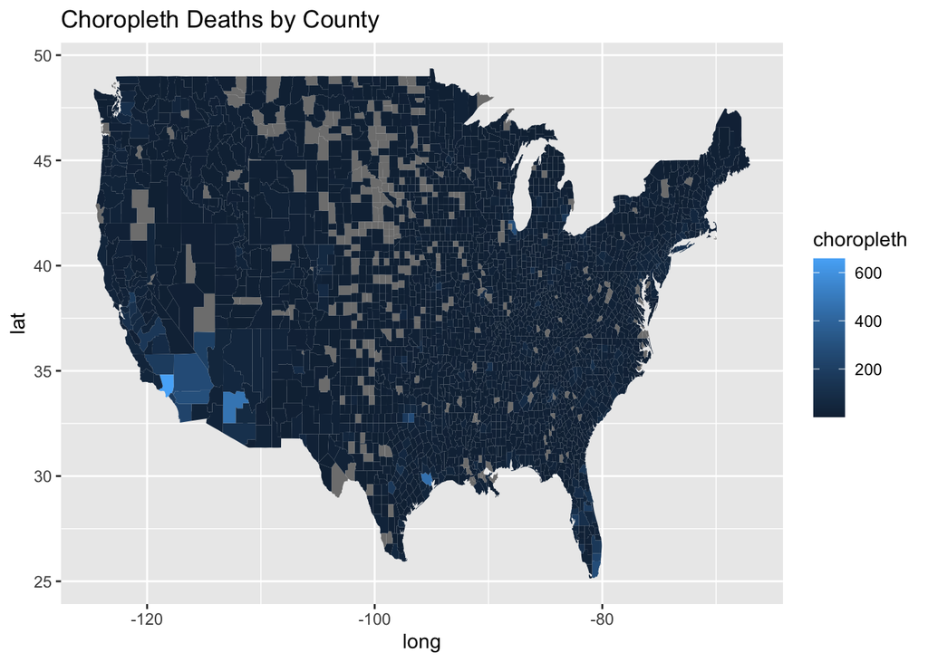

```r
counties <- map_data("county")

condea <- acc %>%
  group_by(STATE, COUNTY) %>%
  summarise(choropleth = sum(FATALS))

glc2 <- glc %>%
  rename(STATE=`State Code`, COUNTY=`County Code`) %>%
  mutate(STATE=as.numeric(STATE), COUNTY=as.numeric(COUNTY))

choro <- condea %>%
  inner_join(glc2, by=c("STATE", "COUNTY")) %>%
  select(choropleth,`State Name`, `County Name`) %>%
  distinct() %>%
  rename(region=`State Name`, subregion=`County Name`) %>%
  mutate(region=tolower(region), subregion=tolower(subregion))%>%
  right_join(counties, by=c("region", "subregion")) %>%
  ggplot(aes(x = long, y = lat, fill = choropleth), color = 'gray') +
  geom_polygon(aes(group=group)) +
  ggtitle("Choropleth Deaths by County")

choro
```

8. Is summer or winter more dangerous? Does this depend on states? Explore and explain.

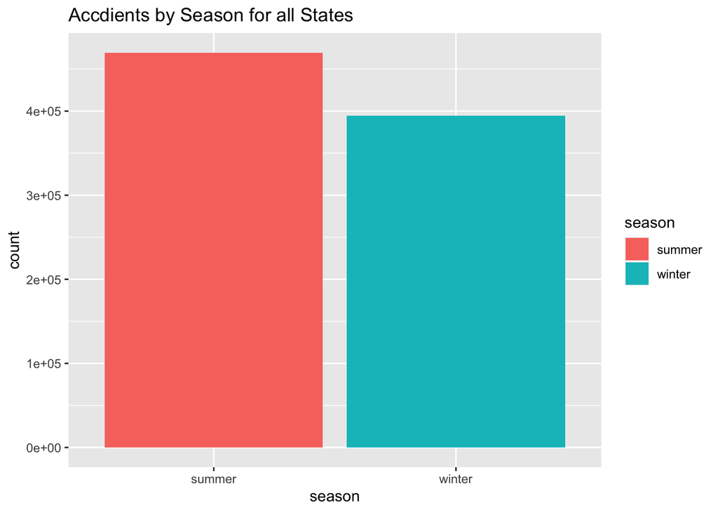

```r
summer <- acc %>%
  filter(MONTH %in% c(6, 7, 8)) %>%
  group_by(STATE)
sum <- summer %>% summarize(count=nrow(summer))
sum$season <- 'summer'

winter <- acc %>%
  filter(MONTH %in% c(12, 1, 2)) %>%
  group_by(STATE)
win <-winter %>% summarize(count=nrow(winter))
win$season <- 'winter'

season <- merge(sum, win, all=TRUE)

ggplot(season ,aes(x = season, y = count, fill = season)) +
  geom_bar(stat='identity') +
  ggtitle("Accdients by Season for all States")
```

Summer seems more dangerous than winter.